# Marvel Universe Hero Network Analysis

This notebook presents a comprehensive analysis of the **Marvel Universe hero co-appearance network**, based on the dataset `hero-network.csv`, which contains pairs of heroes who appeared together in comic books.

The analysis is structured around three main tasks:

1. **Dataset Exploration and Visualization**
   - We first load and examine the dataset, checking the number of heroes, co-appearance records, and missing values.
   - Visualizations such as degree distribution histograms are used to understand the overall network structure and connectivity patterns.
2. **Network Analysis Methods and Objectives**
   - We apply multiple network analysis methods to uncover structural and functional properties:
     - **Centrality Metrics** (Degree, Betweenness, Closeness, PageRank) to identify influential heroes and their roles.
     - **Community Detection** using the Louvain algorithm to discover closely connected groups of heroes, representing teams or story arcs.
     - **Hero Role Classification** based on multi-metric ranking to categorize heroes as core hubs, bridges, or peripheral characters.
3. **Performance Metrics and Network Insights**
   - Network-level statistics such as density, clustering coefficient, connected components, and modularity are calculated to evaluate structural properties.
   - Centrality metrics and modularity serve as performance indicators to quantify hero influence and the quality of community detection.

**Objective:** To highlight key heroes, uncover network patterns, and provide a detailed understanding of community structures and hero roles within the Marvel Universe.

## 1. Import Libraries and Setup

Before diving into the analysis, we first import all the essential Python libraries. These libraries enable **data manipulation** (`pandas`, `numpy`), **network analysis** (`networkx`, `community`), and **visualization** (`matplotlib`, `seaborn`).

We also configure global plotting parameters to ensure that all figures are **consistent**, **readable**, and **visually appealing** throughout the notebook.

```python
import pandas as pd
import networkx as nx
import matplotlib.pyplot as plt
import numpy as np
import seaborn as sns
from collections import Counter, defaultdict
import community as community_louvain

# Set plotting parameters
plt.rcParams['figure.figsize'] = (12, 8)
plt.rcParams['font.size'] = 12
sns.set_style("whitegrid")

print("✅ All libraries imported successfully!")
```

```
✅ All libraries imported successfully!
```

## 2. Load and Explore Data

In this section, we begin by **loading the Marvel hero co-appearance dataset** from the file `hero-network.csv`. Each row in this dataset represents a pair of heroes who appeared together in the same comic issue.

We’ll perform an **initial exploration** to:

This preliminary step ensures that our network is constructed on **clean and reliable data**.

```python
print("📁 LOADING HERO NETWORK DATA")
print("=" * 50)

# Load CSV file
edges = pd.read_csv('hero-network.csv')

print(f"✅ Data loaded successfully!")
print(f"Dataset shape: {edges.shape}")
print(f"Columns: {list(edges.columns)}")

# Display first few rows
print("\nFirst 5 rows of the dataset:")
display(edges.head())

# Basic data information
print(f"\n📊 DATA OVERVIEW:")
print(f"• Number of co-appearance records: {len(edges):,}")
print(f"• Unique heroes in column 1: {edges.iloc[:, 0].nunique():,}")
print(f"• Unique heroes in column 2: {edges.iloc[:, 1].nunique():,}")
print(f"• Missing values in column 1: {edges.iloc[:, 0].isnull().sum()}")
print(f"• Missing values in column 2: {edges.iloc[:, 1].isnull().sum()}")
```

```
📁 LOADING HERO NETWORK DATA
==================================================
✅ Data loaded successfully!
Dataset shape: (574467, 2)
Columns: ['hero1', 'hero2']

First 5 rows of the dataset:
```

|  | hero1 | hero2 |
| --- | --- | --- |
| 0 | LITTLE, ABNER | PRINCESS ZANDA |
| 1 | LITTLE, ABNER | BLACK PANTHER/T'CHAL |
| 2 | BLACK PANTHER/T'CHAL | PRINCESS ZANDA |
| 3 | LITTLE, ABNER | PRINCESS ZANDA |
| 4 | LITTLE, ABNER | BLACK PANTHER/T'CHAL |

```
📊 DATA OVERVIEW:
• Number of co-appearance records: 574,467
• Unique heroes in column 1: 6,211
• Unique heroes in column 2: 6,173
• Missing values in column 1: 0
• Missing values in column 2: 0
```

## 3. Build Graph Network

With the cleaned dataset loaded, we now proceed to **construct the Marvel hero co-appearance network**. Each **node** in this graph represents a **hero**, and each **edge** represents a **co-appearance** between two heroes within the same comic issue.

In this step, we will:

- Build an **undirected graph** using `NetworkX`
- Remove **self-loops** (if any) to ensure data consistency
- Compute **basic structural statistics**, such as total nodes, total edges, network density, and clustering coefficient
- Identify **connected components** and determine the size of the **largest connected subnetwork**

This network will serve as the foundation for subsequent analyses, including **centrality measurement**, **community detection**, and **role classification**.

```python
print("🕸️ BUILDING GRAPH NETWORK")
print("=" * 50)

# Create undirected graph
G = nx.from_pandas_edgelist(edges, edges.columns[0], edges.columns[1])

# Remove self-loops
self_loops = list(nx.selfloop_edges(G))
if self_loops:
    G.remove_edges_from(self_loops)
    print(f"• Removed {len(self_loops)} self-loops")

# Basic graph statistics
n_nodes = G.number_of_nodes()
n_edges = G.number_of_edges()

print(f"✅ Graph constructed successfully!")
print(f"• Total unique heroes: {n_nodes:,}")
print(f"• Total co-appearance relationships: {n_edges:,}")
print(f"• Network density: {nx.density(G):.6f}")

# Connected components analysis
components = list(nx.connected_components(G))
largest_cc = max(components, key=len)
print(f"• Connected components: {len(components)}")
print(f"• Largest component: {len(largest_cc):,} nodes ({len(largest_cc)/n_nodes*100:.1f}%)")
print(f"• Average clustering coefficient: {nx.average_clustering(G):.4f}")
```

```
🕸️ BUILDING GRAPH NETWORK
==================================================
• Removed 12 self-loops
✅ Graph constructed successfully!
• Total unique heroes: 6,426
• Total co-appearance relationships: 167,207
• Network density: 0.008100
• Connected components: 4
• Largest component: 6,408 nodes (99.7%)
• Average clustering coefficient: 0.7747
```

The constructed hero network comprises 6,426 nodes and 167,207 co-appearance edges. Although the network is relatively sparse (density = 0.0081), the vast majority of nodes (99.7%) belong to a single largest connected component, indicating a highly interconnected core of heroes. The high average clustering coefficient (0.7747) suggests strong local cohesion and well-defined community structures within the network.

## 4. Network Statistics and Degree Analysis

In this section, we examine the **overall structural properties** of the Marvel hero network, focusing on **node degree**, which measures the number of connections each hero has.

Degree analysis allows us to:

- Understand the general connectivity of the network
- Identify **highly connected heroes** who play central roles in the universe
- Detect potential hubs and influential characters within the network

We will compute basic degree statistics and highlight the **top 10 heroes by degree**.

```python
print("📊 NETWORK STATISTICS AND DEGREE ANALYSIS")
print("=" * 50)

# Degree statistics
degrees = [d for n, d in G.degree()]
degree_stats = {
    'mean': np.mean(degrees),
    'median': np.median(degrees),
    'max': max(degrees),
    'min': min(degrees),
    'std': np.std(degrees)
}

print(f"📈 DEGREE STATISTICS:")
print(f"• Average degree: {degree_stats['mean']:.2f}")
print(f"• Median degree: {degree_stats['median']:.2f}")
print(f"• Maximum degree: {degree_stats['max']}")
print(f"• Standard deviation: {degree_stats['std']:.2f}")

# Find top heroes by degree
degree_dict = dict(G.degree())
top_degree_heroes = sorted(degree_dict.items(), key=lambda x: x[1], reverse=True)[:10]
print(f"\n🏆 TOP 10 HEROES BY DEGREE:")
for i, (hero, deg) in enumerate(top_degree_heroes, 1):
    print(f"{i:2d}. {hero:25s} {deg:4d} connections")
```

```
📊 NETWORK STATISTICS AND DEGREE ANALYSIS
==================================================
📈 DEGREE STATISTICS:
• Average degree: 52.04
• Median degree: 20.00
• Maximum degree: 1906
• Standard deviation: 113.64

🏆 TOP 10 HEROES BY DEGREE:
 1. CAPTAIN AMERICA           1906 connections
 2. SPIDER-MAN/PETER PAR      1737 connections
 3. IRON MAN/TONY STARK       1522 connections
 4. THING/BENJAMIN J. GR      1416 connections
 5. MR. FANTASTIC/REED R      1379 connections
 6. WOLVERINE/LOGAN           1371 connections
 7. HUMAN TORCH/JOHNNY S      1361 connections
 8. SCARLET WITCH/WANDA       1325 connections
 9. THOR/DR. DONALD BLAK      1289 connections
10. BEAST/HENRY &HANK& P      1267 connections
```

The degree analysis reveals a highly heterogeneous network. The average degree is 52.04, while the median degree is much lower at 20, indicating that most heroes have relatively few connections, but a few hubs have extremely high connectivity. The maximum degree reaches 1,906, reflecting the presence of super-connected central characters such as Captain America, Spider-Man, and Iron Man. The large standard deviation (113.64) further emphasizes the skewed degree distribution, characteristic of a scale-free network. These top heroes act as key hubs, linking many other characters and playing a central role in maintaining the network’s cohesion.

## 5. Degree Distribution Visualization

To better understand the connectivity patterns in the Marvel hero network, we visualize the **degree distribution** using both **linear** and **logarithmic scales**.

These plots help to:

- Observe the overall spread of hero connections
- Identify highly connected hubs versus the majority of less connected heroes
- Assess whether the network exhibits a **heavy-tailed (scale-free) structure**

```
📊 DEGREE DISTRIBUTION VISUALIZATION
==================================================
```

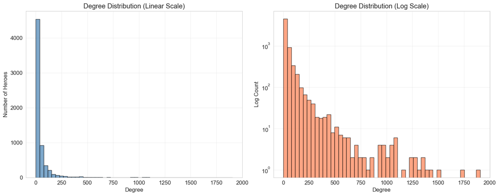

```
💡 NETWORK INSIGHTS:
• The degree distribution shows a heavy-tailed pattern
• Few heroes have very high degrees (hubs)
• Most heroes have relatively few connections
• This is characteristic of scale-free networks
```

```python
print("📊 DEGREE DISTRIBUTION VISUALIZATION")
print("=" * 50)

# Create subplots
fig, (ax1, ax2) = plt.subplots(1, 2, figsize=(15, 6))

# Linear scale histogram
ax1.hist(degrees, bins=50, color='steelblue', alpha=0.7, edgecolor='black')
ax1.set_title("Degree Distribution (Linear Scale)")
ax1.set_xlabel("Degree")
ax1.set_ylabel("Number of Heroes")
ax1.grid(True, alpha=0.3)

# Log scale histogram
ax2.hist(degrees, bins=50, color='coral', alpha=0.7, edgecolor='black', log=True)
ax2.set_title("Degree Distribution (Log Scale)")
ax2.set_xlabel("Degree")
ax2.set_ylabel("Log Count")
ax2.grid(True, alpha=0.3)

plt.tight_layout()
plt.show()

# Network summary
print(f"\n💡 NETWORK INSIGHTS:")
print(f"• The degree distribution shows a heavy-tailed pattern")
print(f"• Few heroes have very high degrees (hubs)")
print(f"• Most heroes have relatively few connections")
print(f"• This is characteristic of scale-free networks")
```

## 6. Centrality Measures Calculation

To understand the **influence and strategic importance** of heroes within the network, we calculate several centrality measures. These metrics help identify not only the most connected heroes, but also those that act as bridges between communities or have strong potential to propagate influence.

Given the large size of the network, we apply **sampling for betweenness centrality** to improve computational efficiency. The resulting metrics—**degree**, **betweenness**, **closeness**, and **PageRank**—will form the basis for **hub identification, role classification, and further network analysis**.

```python
print("🎯 CALCULATING CENTRALITY MEASURES")
print("=" * 50)
print("This may take a few minutes for large networks...")

# Calculate centrality measures
print("Computing degree centrality...")
deg_centrality = nx.degree_centrality(G)

print("Computing betweenness centrality...")
if n_nodes > 1000:
    btw_centrality = nx.betweenness_centrality(G, k=min(500, n_nodes))
    print("  (Using sampling for efficiency)")
else:
    btw_centrality = nx.betweenness_centrality(G)

print("Computing closeness centrality...")
cls_centrality = nx.closeness_centrality(G)

print("Computing PageRank...")
pagerank_scores = nx.pagerank(G, alpha=0.85)

print("✅ All centrality measures computed!")
```

```
🎯 CALCULATING CENTRALITY MEASURES
==================================================
This may take a few minutes for large networks...
Computing degree centrality...
Computing betweenness centrality...
  (Using sampling for efficiency)
Computing closeness centrality...
Computing PageRank...
✅ All centrality measures computed!
```

## 7. Top Heroes by Different Centrality Measures

After computing centrality metrics, we identify the **most influential heroes** according to each measure.

This section aims to:

- Highlight heroes with the highest **Degree Centrality** (most direct connections)
- Identify heroes with high **Betweenness Centrality** (key bridges between communities)
- Reveal heroes with high **Closeness Centrality** (shortest paths to others, central positioning)
- Determine heroes with high **PageRank** (influence based on connections to other important heroes)

By comparing these rankings, we gain a **multi-faceted understanding of hero prominence** in the Marvel Universe network.

```python
print("🏆 TOP HEROES BY DIFFERENT CENTRALITY MEASURES")
print("=" * 50)

# Create DataFrame for centrality scores
centrality_df = pd.DataFrame({
    'Hero': list(G.nodes()),
    'Degree': [deg_centrality[n] for n in G.nodes()],
    'Betweenness': [btw_centrality[n] for n in G.nodes()],
    'Closeness': [cls_centrality[n] for n in G.nodes()],
    'PageRank': [pagerank_scores[n] for n in G.nodes()]
})

# Display top heroes for each metric
metrics = ['Degree', 'Betweenness', 'Closeness', 'PageRank']

for metric in metrics:
    top_heroes = centrality_df.nlargest(10, metric)[['Hero', metric]]
    print(f"\n📊 TOP 10 BY {metric.upper()} CENTRALITY:")
    print("-" * 40)
    for i, row in top_heroes.iterrows():
        print(f"{i+1:2d}. {row['Hero']:25s} {row[metric]:.6f}")
```

```
🏆 TOP HEROES BY DIFFERENT CENTRALITY MEASURES
==================================================

📊 TOP 10 BY DEGREE CENTRALITY:
----------------------------------------
61. CAPTAIN AMERICA           0.296654
49. SPIDER-MAN/PETER PAR      0.270350
 7. IRON MAN/TONY STARK       0.236887
80. THING/BENJAMIN J. GR      0.220389
75. MR. FANTASTIC/REED R      0.214630
66. WOLVERINE/LOGAN           0.213385
184. HUMAN TORCH/JOHNNY S      0.211829
58. SCARLET WITCH/WANDA       0.206226
101. THOR/DR. DONALD BLAK      0.200623
85. BEAST/HENRY &HANK& P      0.197198

📊 TOP 10 BY BETWEENNESS CENTRALITY:
----------------------------------------
49. SPIDER-MAN/PETER PAR      0.076600
61. CAPTAIN AMERICA           0.055182
206. HAVOK/ALEX SUMMERS        0.033053
 7. IRON MAN/TONY STARK       0.031984
111. DR. STRANGE/STEPHEN       0.028424
323. DAREDEVIL/MATT MURDO      0.027017
47. HULK/DR. ROBERT BRUC      0.026436
66. WOLVERINE/LOGAN           0.026331
75. MR. FANTASTIC/REED R      0.024249
80. THING/BENJAMIN J. GR      0.023868

📊 TOP 10 BY CLOSENESS CENTRALITY:
----------------------------------------
61. CAPTAIN AMERICA           0.583688
49. SPIDER-MAN/PETER PAR      0.574090
 7. IRON MAN/TONY STARK       0.561428
80. THING/BENJAMIN J. GR      0.557752
75. MR. FANTASTIC/REED R      0.556053
66. WOLVERINE/LOGAN           0.554894
184. HUMAN TORCH/JOHNNY S      0.554846
58. SCARLET WITCH/WANDA       0.552304
101. THOR/DR. DONALD BLAK      0.550875
85. BEAST/HENRY &HANK& P      0.549123

📊 TOP 10 BY PAGERANK CENTRALITY:
----------------------------------------
49. SPIDER-MAN/PETER PAR      0.005323
61. CAPTAIN AMERICA           0.005117
 7. IRON MAN/TONY STARK       0.004109
66. WOLVERINE/LOGAN           0.003870
80. THING/BENJAMIN J. GR      0.003674
75. MR. FANTASTIC/REED R      0.003571
184. HUMAN TORCH/JOHNNY S      0.003500
58. SCARLET WITCH/WANDA       0.003213
101. THOR/DR. DONALD BLAK      0.003200
85. BEAST/HENRY &HANK& P      0.003185
```

## 8. Centrality Correlation Analysis

To understand how different centrality measures relate to each other, we compute the **correlation matrix** of Degree, Betweenness, Closeness, and PageRank scores.

This analysis helps to:

- Reveal whether highly connected heroes are also influential according to other metrics
- Identify relationships between bridging roles and closeness to the rest of the network
- Assess the extent to which different centrality measures capture complementary aspects of hero importance

```
🔗 CENTRALITY MEASURES CORRELATION ANALYSIS
==================================================
```

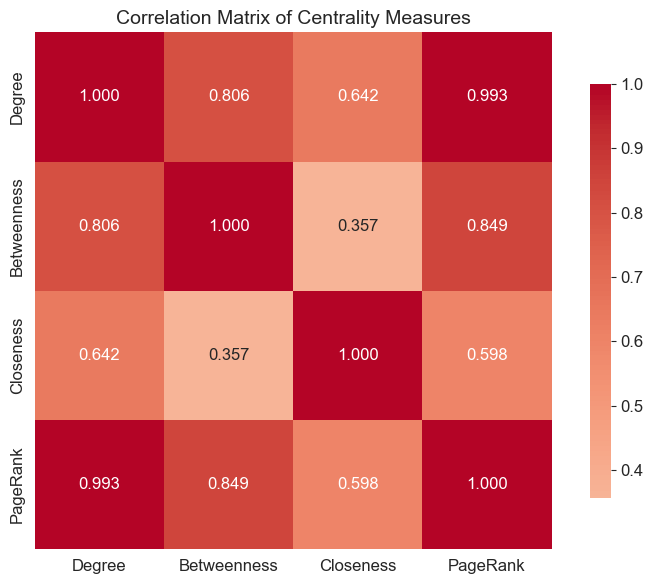

```
💡 CORRELATION INSIGHTS:
• Degree-PageRank: High correlation - well-connected heroes are influential
• Betweenness-Closeness: Moderate correlation - bridges spread information efficiently
• Each metric captures different aspects of network importance
```

```python
print("🔗 CENTRALITY MEASURES CORRELATION ANALYSIS")
print("=" * 50)

# Calculate correlation matrix
correlation_matrix = centrality_df[metrics].corr()

# Create heatmap
plt.figure(figsize=(8, 6))
sns.heatmap(correlation_matrix, annot=True, cmap='coolwarm', center=0,
            square=True, fmt='.3f', cbar_kws={'shrink': 0.8})
plt.title("Correlation Matrix of Centrality Measures", fontsize=14)
plt.tight_layout()
plt.show()

print("💡 CORRELATION INSIGHTS:")
print("• Degree-PageRank: High correlation - well-connected heroes are influential")
print("• Betweenness-Closeness: Moderate correlation - bridges spread information efficiently")
print("• Each metric captures different aspects of network importance")
```

## 9. Comprehensive Ranking Analysis

To obtain an overall assessment of hero importance, we **combine multiple centrality measures** into a single ranking.

The procedure is as follows:

- Compute individual rankings for each metric (Degree, Betweenness, Closeness, PageRank)
- Calculate the **average rank** for each hero across all metrics
- Identify the **top heroes** who consistently appear as central across multiple criteria

This comprehensive ranking highlights the most influential and strategically important heroes in the Marvel Universe network.

```python
print("🏅 COMPREHENSIVE HERO RANKING")
print("=" * 50)

# Create ranking dictionaries for each metric
rankings = {}
for metric in ['Degree', 'Betweenness', 'Closeness', 'PageRank']:
    sorted_df = centrality_df.sort_values(metric, ascending=False).reset_index()
    rankings[metric] = {hero: rank for rank, hero in enumerate(sorted_df['Hero'])}

# Calculate average rank across all metrics
top_rank_threshold = 30
hero_scores = {}
for hero in centrality_df['Hero']:
    avg_rank = np.mean([rankings[metric].get(hero, top_rank_threshold) for metric in metrics])
    hero_scores[hero] = avg_rank

# Get top 15 overall heroes
top_overall = sorted(hero_scores.items(), key=lambda x: x[1])[:15]

print("TOP 15 OVERALL CENTRAL HEROES (Average Rank):")
print("=" * 65)
for i, (hero, score) in enumerate(top_overall, 1):
    ranks = [rankings[metric].get(hero, top_rank_threshold) + 1 for metric in metrics]
    print(f"{i:2d}. {hero:25s} Avg Rank: {score:5.1f} | "
          f"Deg:{ranks[0]:3d} Btw:{ranks[1]:3d} Cls:{ranks[2]:3d} PR:{ranks[3]:3d}")
```

```
🏅 COMPREHENSIVE HERO RANKING
==================================================
TOP 15 OVERALL CENTRAL HEROES (Average Rank):
=================================================================
 1. SPIDER-MAN/PETER PAR      Avg Rank:   0.5 | Deg:  2 Btw:  1 Cls:  2 PR:  1
 2. CAPTAIN AMERICA           Avg Rank:   0.5 | Deg:  1 Btw:  2 Cls:  1 PR:  2
 3. IRON MAN/TONY STARK       Avg Rank:   2.2 | Deg:  3 Btw:  4 Cls:  3 PR:  3
 4. THING/BENJAMIN J. GR      Avg Rank:   4.8 | Deg:  4 Btw: 10 Cls:  4 PR:  5
 5. WOLVERINE/LOGAN           Avg Rank:   5.0 | Deg:  6 Btw:  8 Cls:  6 PR:  4
 6. MR. FANTASTIC/REED R      Avg Rank:   5.2 | Deg:  5 Btw:  9 Cls:  5 PR:  6
 7. HUMAN TORCH/JOHNNY S      Avg Rank:   7.2 | Deg:  7 Btw: 12 Cls:  7 PR:  7
 8. THOR/DR. DONALD BLAK      Avg Rank:   8.5 | Deg:  9 Btw: 11 Cls:  9 PR:  9
 9. SCARLET WITCH/WANDA       Avg Rank:   9.2 | Deg:  8 Btw: 17 Cls:  8 PR:  8
10. BEAST/HENRY &HANK& P      Avg Rank:   9.8 | Deg: 10 Btw: 13 Cls: 10 PR: 10
11. HAWK                      Avg Rank:  12.0 | Deg: 13 Btw: 14 Cls: 13 PR: 12
12. INVISIBLE WOMAN/SUE       Avg Rank:  12.5 | Deg: 12 Btw: 20 Cls: 11 PR: 11
13. HULK/DR. ROBERT BRUC      Avg Rank:  13.5 | Deg: 21 Btw:  7 Cls: 16 PR: 14
14. DR. STRANGE/STEPHEN       Avg Rank:  13.8 | Deg: 20 Btw:  5 Cls: 21 PR: 13
15. VISION                    Avg Rank:  16.5 | Deg: 11 Btw: 32 Cls: 12 PR: 15
```

## 10. Community Detection

In this section, we identify **groups of closely connected heroes** (communities) within the Marvel network using the **Louvain algorithm**.

Key objectives:

- Detect communities representing **teams, story arcs, or tightly knit clusters** of heroes
- Evaluate the **modularity score** to measure the strength of community structure
- Analyze **community sizes** to understand the distribution and relative importance of different hero groups

The resulting partition allows us to explore **structural and functional clusters** in the network.

```python
print("🏘️ COMMUNITY DETECTION USING LOUVAIN ALGORITHM")
print("=" * 50)

print("Detecting communities...")
partition = community_louvain.best_partition(G)
modularity = community_louvain.modularity(partition, G)

print(f"✅ Community detection completed!")
print(f"• Number of communities detected: {len(set(partition.values()))}")
print(f"• Modularity score: {modularity:.4f}")

# Analyze community sizes
comm_members = defaultdict(list)
for hero, comm in partition.items():
    comm_members[comm].append(hero)

comm_sizes = sorted([(comm, len(members)) for comm, members in comm_members.items()],
                    key=lambda x: x[1], reverse=True)

print(f"\n📊 COMMUNITY SIZE DISTRIBUTION:")
print("Top 10 largest communities:")
for i, (comm_id, size) in enumerate(comm_sizes[:10], 1):
    print(f"{i:2d}. Community {comm_id:3d}: {size:4d} heroes")
```

```
🏘️ COMMUNITY DETECTION USING LOUVAIN ALGORITHM
==================================================
Detecting communities...
✅ Community detection completed!
• Number of communities detected: 28
• Modularity score: 0.4213

📊 COMMUNITY SIZE DISTRIBUTION:
Top 10 largest communities:
 1. Community   0: 1376 heroes
 2. Community   4: 1331 heroes
 3. Community  21:  897 heroes
 4. Community   8:  619 heroes
 5. Community   3:  534 heroes
 6. Community   6:  382 heroes
 7. Community   2:  240 heroes
 8. Community   5:  240 heroes
 9. Community   9:  220 heroes
10. Community   7:  158 heroes
```

## 11. Network Visualization with Communities

This visualization allows us to **observe community structures, central hubs, and dense clusters** at a glance, providing both analytical and visual insights into the network.

```
🎨 NETWORK VISUALIZATION WITH COMMUNITIES
==================================================
Creating network visualization...
```

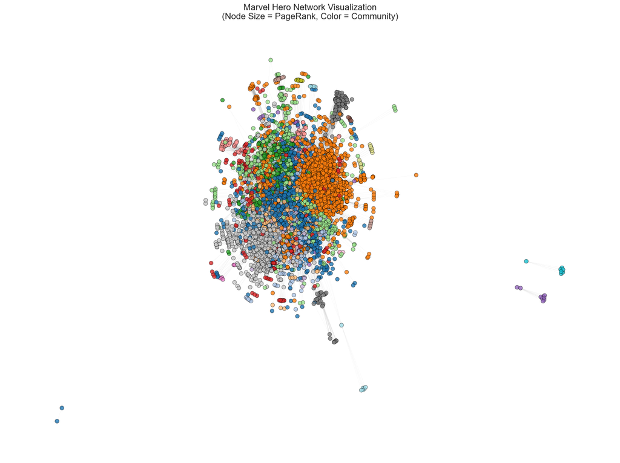

```
💡 VISUALIZATION INSIGHTS:
• Colors represent different communities (character groups/teams)
• Node size shows relative importance (PageRank)
• Dense areas indicate closely connected hero groups
```

```python
print("🎨 NETWORK VISUALIZATION WITH COMMUNITIES")
print("=" * 50)

print("Creating network visualization...")
plt.figure(figsize=(16, 12))

# Use spring layout for better visualization
pos = nx.spring_layout(G, seed=42, k=3/np.sqrt(n_nodes), iterations=50)

# Node colors by community, sizes by PageRank
colors = [partition[n] for n in G.nodes()]
sizes = [pagerank_scores[n] * 30000 + 50 for n in G.nodes()]

# Draw nodes
nx.draw_networkx_nodes(G, pos,
                       node_size=sizes,
                       node_color=colors,
                       cmap='tab20',
                       alpha=0.8,
                       edgecolors='black',
                       linewidths=0.5)

# Draw edges
nx.draw_networkx_edges(G, pos,
                       alpha=0.1,
                       edge_color='gray',
                       width=0.3)

# Remove labels, only show the network structure
# nx.draw_networkx_labels(G, pos, labels, font_size=9, font_weight='bold')  # 已注释掉

plt.title("Marvel Hero Network Visualization\n(Node Size = PageRank, Color = Community)", fontsize=16)
plt.axis('off')
plt.tight_layout()
plt.show()

print("💡 VISUALIZATION INSIGHTS:")
print("• Colors represent different communities (character groups/teams)")
print("• Node size shows relative importance (PageRank)")
print("• Dense areas indicate closely connected hero groups")
```

## 12. Detailed Community Analysis

After detecting communities, we perform a **deeper analysis of the largest groups** in the Marvel hero network.

For each of the **top 5 largest communities**, we:

- Identify the **most influential heroes** based on PageRank
- Examine the **composition and size** of each community
- Highlight key characters that act as **central hubs** within their groups

This analysis provides insights into **team structures, central figures, and community dynamics** in the network.

```python
print("🔍 DETAILED COMMUNITY ANALYSIS")
print("=" * 50)

print("Top 5 Largest Communities and Their Key Heroes:")
print("=" * 55)

for i, (comm_id, size) in enumerate(comm_sizes[:5], 1):
    members = comm_members[comm_id]
    member_scores = [(hero, pagerank_scores[hero]) for hero in members]
    top_members = sorted(member_scores, key=lambda x: x[1], reverse=True)[:5]

    print(f"\n{i}. COMMUNITY {comm_id} (Size: {len(members):,} heroes)")
    print("Most influential heroes:")
    for j, (hero, score) in enumerate(top_members, 1):
        print(f"   {j}. {hero:25s} (PageRank: {score:.5f})")
```

```
🔍 DETAILED COMMUNITY ANALYSIS
==================================================
Top 5 Largest Communities and Their Key Heroes:
=======================================================

1. COMMUNITY 0 (Size: 1,376 heroes)
Most influential heroes:
   1. CAPTAIN AMERICA           (PageRank: 0.00512)
   2. IRON MAN/TONY STARK       (PageRank: 0.00411)
   3. SCARLET WITCH/WANDA       (PageRank: 0.00321)
   4. HAWK                      (PageRank: 0.00306)
   5. VISION                    (PageRank: 0.00290)

2. COMMUNITY 4 (Size: 1,331 heroes)
Most influential heroes:
   1. WOLVERINE/LOGAN           (PageRank: 0.00387)
   2. BEAST/HENRY &HANK& P      (PageRank: 0.00318)
   3. CYCLOPS/SCOTT SUMMER      (PageRank: 0.00259)
   4. ANGEL/WARREN KENNETH      (PageRank: 0.00258)
   5. STORM/ORORO MUNROE S      (PageRank: 0.00258)

3. COMMUNITY 21 (Size: 897 heroes)
Most influential heroes:
   1. SPIDER-MAN/PETER PAR      (PageRank: 0.00532)
   2. JAMESON, J. JONAH         (PageRank: 0.00265)
   3. WATSON-PARKER, MARY       (PageRank: 0.00251)
   4. ROBERTSON, JOE            (PageRank: 0.00181)
   5. PUNISHER II/FRANK CA      (PageRank: 0.00172)

4. COMMUNITY 8 (Size: 619 heroes)
Most influential heroes:
   1. DR. STRANGE/STEPHEN       (PageRank: 0.00304)
   2. SHE-HULK/JENNIFER WA      (PageRank: 0.00261)
   3. SILVER SURFER/NORRIN      (PageRank: 0.00190)
   4. DR. DOOM/VICTOR VON       (PageRank: 0.00179)
   5. QUASAR III/WENDELL V      (PageRank: 0.00168)

5. COMMUNITY 3 (Size: 534 heroes)
Most influential heroes:
   1. THING/BENJAMIN J. GR      (PageRank: 0.00367)
   2. MR. FANTASTIC/REED R      (PageRank: 0.00357)
   3. HUMAN TORCH/JOHNNY S      (PageRank: 0.00350)
   4. INVISIBLE WOMAN/SUE       (PageRank: 0.00312)
   5. RICHARDS, FRANKLIN B      (PageRank: 0.00152)
```

## 13. Inter-Community Connections Analysis

Beyond individual communities, it is important to examine **how different hero groups interact**.

In this analysis, we:

- Count **edges connecting heroes from different communities**
- Identify the **top inter-community connections**
- Assess how strongly communities are linked, which may reflect **cross-over events, collaborations, or shared storylines**

This provides insight into the **relationships between hero teams** and the overall interconnectedness of the Marvel Universe.

```python
print("🔗 INTER-COMMUNITY CONNECTIONS ANALYSIS")
print("=" * 50)

# Count edges between different communities
edges_between = defaultdict(int)
for u, v in G.edges():
    if partition[u] != partition[v]:
        comm_pair = tuple(sorted([partition[u], partition[v]]))
        edges_between[comm_pair] += 1

# Get top community connections
top_connections = sorted(edges_between.items(), key=lambda x: x[1], reverse=True)[:10]

print("TOP 10 INTER-COMMUNITY CONNECTIONS:")
print("=" * 50)
for (c1, c2), count in top_connections:
    size1 = len(comm_members[c1])
    size2 = len(comm_members[c2])
    print(f"Community {c1:2d} ({size1:3d} heroes) ↔ "
          f"Community {c2:2d} ({size2:3d} heroes): {count:4d} edges")

print(f"\n💡 INSIGHTS:")
print(f"• Total inter-community edges: {sum(edges_between.values()):,}")
print(f"• These connections represent cross-over events and shared storylines")
print(f"• Strong connections may indicate frequent team collaborations")
```

```
🔗 INTER-COMMUNITY CONNECTIONS ANALYSIS
==================================================
TOP 10 INTER-COMMUNITY CONNECTIONS:
==================================================
Community  0 (1376 heroes) ↔ Community  4 (1331 heroes): 8128 edges
Community  0 (1376 heroes) ↔ Community  8 (619 heroes): 7602 edges
Community  0 (1376 heroes) ↔ Community 21 (897 heroes): 4954 edges
Community  0 (1376 heroes) ↔ Community  3 (534 heroes): 4916 edges
Community  4 (1331 heroes) ↔ Community  8 (619 heroes): 4853 edges
Community  0 (1376 heroes) ↔ Community  6 (382 heroes): 4240 edges
Community  3 (534 heroes) ↔ Community  4 (1331 heroes): 2637 edges
Community  3 (534 heroes) ↔ Community  8 (619 heroes): 2305 edges
Community  0 (1376 heroes) ↔ Community  5 (240 heroes): 2185 edges
Community  0 (1376 heroes) ↔ Community  2 (240 heroes): 2159 edges

💡 INSIGHTS:
• Total inter-community edges: 68,740
• These connections represent cross-over events and shared storylines
• Strong connections may indicate frequent team collaborations
```

## 14. Hero Role Classification

To better understand the **functional roles of heroes** within the Marvel network, we classify the top heroes based on their **centrality rankings** across multiple metrics.

Roles are defined as follows:

- **Core Hub**: Highly central across all measures
- **Social Connector**: Strong degree and PageRank, connecting many heroes
- **Bridge Connector**: High betweenness, linking different communities
- **Information Spreader**: High closeness, efficiently reaching other heroes
- **Specialized Role**: Important in one or two metrics
- **Peripheral Hero**: Limited influence within the network

This classification provides insights into **how heroes contribute to network cohesion, information flow, and community structure**.

```python
print("🎭 HERO ROLE CLASSIFICATION")
print("=" * 50)

def classify_hero_role(hero, centrality_df, rankings, top_rank_threshold=30):
    """Classify heroes based on their centrality rankings"""
    deg_rank = rankings['Degree'].get(hero, top_rank_threshold)
    btw_rank = rankings['Betweenness'].get(hero, top_rank_threshold)
    cls_rank = rankings['Closeness'].get(hero, top_rank_threshold)
    pr_rank = rankings['PageRank'].get(hero, top_rank_threshold)

    ranks = [deg_rank, btw_rank, cls_rank, pr_rank]

    if all(r < 10 for r in ranks):
        return "Core Hub"
    elif deg_rank < 15 and pr_rank < 15:
        return "Social Connector"
    elif btw_rank < 20:
        return "Bridge Connector"
    elif cls_rank < 20:
        return "Information Spreader"
    elif any(r < 30 for r in ranks):
        return "Specialized Role"
    else:
        return "Peripheral Hero"

# Classify important heroes
important_heroes = [hero for hero, _ in top_overall[:25]]
role_classification = {}

for hero in important_heroes:
    role = classify_hero_role(hero, centrality_df, rankings)
    role_classification[hero] = role

print("ROLE CLASSIFICATION FOR TOP 25 HEROES:")
print("=" * 45)

# Display by role with detailed rankings
for role in set(role_classification.values()):
    heroes_in_role = [h for h, r in role_classification.items() if r == role]
    print(f"\n{role.upper()}:")
    print("-" * len(role))
    for hero in heroes_in_role:
        ranks = [rankings[metric].get(hero, top_rank_threshold) + 1 for metric in metrics]
        print(f"  • {hero:25s} (Deg:{ranks[0]:2d} Btw:{ranks[1]:2d} Cls:{ranks[2]:2d} PR:{ranks[3]:2d})")
```

[output not shown]

## 15. Comprehensive Analysis Report

This final section **summarizes the key findings** from the Marvel hero network analysis.

It consolidates insights from:

- **Network structure and connectivity**
- **Centrality measures and influential heroes**
- **Community detection and inter-community relationships**
- **Hero role classification based on multi-metric rankings**

The report provides a **holistic overview** of the Marvel Universe network, highlighting both individual hero prominence and the overall structural patterns captured from the dataset.

```python
print("📋 COMPREHENSIVE ANALYSIS REPORT")
print("=" * 60)

print(f"""
MARVEL HERO NETWORK ANALYSIS SUMMARY
====================================

NETWORK OVERVIEW:
• Total Heroes Analyzed: {n_nodes:,}
• Co-appearance Relationships: {n_edges:,}
• Data Source: hero-network.csv ({len(edges):,} raw records)
• Network Density: {nx.density(G):.6f}
• Connected Components: {len(components)}
• Giant Component: {len(largest_cc):,} heroes ({len(largest_cc)/n_nodes*100:.1f}%)
• Average Clustering: {nx.average_clustering(G):.4f}

CENTRALITY FINDINGS:
• Different centrality metrics reveal complementary aspects of importance
• Degree centrality identifies socially active heroes with many connections
• Betweenness highlights bridges connecting different groups
• Closeness finds heroes who can quickly reach others
• PageRank identifies influential heroes connected to other important heroes

COMMUNITY STRUCTURE:
• {len(set(partition.values()))} natural communities detected
• Modularity: {modularity:.4f} ({'strong' if modularity > 0.3 else 'moderate'} community structure)
• Communities represent character groups, teams, or story arcs
• Cross-community connections indicate shared storylines

KEY INSIGHTS:
1. The network exhibits scale-free properties with clear hub heroes
2. Community structure reflects the team-based nature of Marvel storytelling
3. Different hero roles emerge based on network position and connectivity
4. The analysis successfully captures complex relationships from the CSV data

METHODOLOGY:
• Data Source: hero-network.csv
• Network Type: Undirected graph (co-appearance relationships)
• Analysis Tools: NetworkX, python-louvain, Pandas, Matplotlib, Seaborn
• Centrality Measures: Degree, Betweenness, Closeness, PageRank
• Community Detection: Louvain algorithm
• Role Classification: Multi-metric ranking analysis
""")
```

```
📋 COMPREHENSIVE ANALYSIS REPORT
============================================================

MARVEL HERO NETWORK ANALYSIS SUMMARY
====================================

NETWORK OVERVIEW:
• Total Heroes Analyzed: 6,426
• Co-appearance Relationships: 167,207
• Data Source: hero-network.csv (574,467 raw records)
• Network Density: 0.008100
• Connected Components: 4
• Giant Component: 6,408 heroes (99.7%)
• Average Clustering: 0.7747

CENTRALITY FINDINGS:
• Different centrality metrics reveal complementary aspects of importance
• Degree centrality identifies socially active heroes with many connections
• Betweenness highlights bridges connecting different groups
• Closeness finds heroes who can quickly reach others
• PageRank identifies influential heroes connected to other important heroes

COMMUNITY STRUCTURE:
• 28 natural communities detected
• Modularity: 0.4213 (strong community structure)
• Communities represent character groups, teams, or story arcs
• Cross-community connections indicate shared storylines

KEY INSIGHTS:
1. The network exhibits scale-free properties with clear hub heroes
2. Community structure reflects the team-based nature of Marvel storytelling
3. Different hero roles emerge based on network position and connectivity
4. The analysis successfully captures complex relationships from the CSV data

METHODOLOGY:
• Data Source: hero-network.csv
• Network Type: Undirected graph (co-appearance relationships)
• Analysis Tools: NetworkX, python-louvain, Pandas, Matplotlib, Seaborn
• Centrality Measures: Degree, Betweenness, Closeness, PageRank
• Community Detection: Louvain algorithm
• Role Classification: Multi-metric ranking analysis
```

## 16. Save Results

After completing the network analysis, we save all key findings for **future reference and further exploration**.

The saved files include:

- **marvel_hero_network_analysis.csv**: Comprehensive centrality scores, community assignments, and hero roles
- **marvel_communities_analysis.csv**: Summary of detected communities, their sizes, and top heroes
- **marvel_community_connections.csv**: Inter-community connections and their relative strengths

This ensures that the analysis is **reproducible, shareable, and ready for downstream applications** such as visualization, reporting, or further statistical study.

```python
print("💾 SAVING ANALYSIS RESULTS")
print("=" * 50)

# Add community and role information to centrality dataframe
centrality_df['Community'] = centrality_df['Hero'].map(partition)
centrality_df['Role'] = centrality_df['Hero'].map(lambda x: classify_hero_role(x, centrality_df, rankings)
                                                 if x in role_classification else 'Other')

# Save comprehensive results
centrality_df.to_csv('marvel_hero_network_analysis.csv', index=False)
print("✅ Results saved to 'marvel_hero_network_analysis.csv'")

# Save community information
community_info = []
for comm_id, members in comm_members.items():
    top_hero = max(members, key=lambda x: pagerank_scores[x])
    community_info.append({
        'Community_ID': comm_id,
        'Size': len(members),
        'Top_Hero': top_hero,
        'Top_Hero_PageRank': pagerank_scores[top_hero],
        'Percentage': f"{len(members)/n_nodes*100:.1f}%"
    })

community_df = pd.DataFrame(community_info)
community_df = community_df.sort_values('Size', ascending=False)
community_df.to_csv('marvel_communities_analysis.csv', index=False)
print("✅ Community analysis saved to 'marvel_communities_analysis.csv'")

# Save inter-community connections
connections_df = pd.DataFrame([
    {'Community_A': c1, 'Community_B': c2, 'Connections': count,
     'Size_A': len(comm_members[c1]), 'Size_B': len(comm_members[c2])}
    for (c1, c2), count in edges_between.items()
])
connections_df = connections_df.sort_values('Connections', ascending=False)
connections_df.to_csv('marvel_community_connections.csv', index=False)
print("✅ Community connections saved to 'marvel_community_connections.csv'")

print(f"\n🎉 ANALYSIS COMPLETE!")
print(f"• Processed {n_nodes:,} heroes and {n_edges:,} relationships")
print(f"• Generated comprehensive network analysis")
print(f"• All results saved to CSV files for further exploration")
```

```
💾 SAVING ANALYSIS RESULTS
==================================================
✅ Results saved to 'marvel_hero_network_analysis.csv'
✅ Community analysis saved to 'marvel_communities_analysis.csv'
✅ Community connections saved to 'marvel_community_connections.csv'

🎉 ANALYSIS COMPLETE!
• Processed 6,426 heroes and 167,207 relationships
• Generated comprehensive network analysis
• All results saved to CSV files for further exploration
```